# Untitled

Søren Højsgaard

2025-01-24

## Preliminaries

```r
library(lme4)
library(nlme)
library(SASmixed)
library(doBy)
library(dataRep)
library(tidyr)
```

```r
library(ggplot2)
library(pbkrtest)
library(knitr)
library(broom.mixed)
```

## Shoes

The shoes data are measurements of the amount wear of the soles of shoes worn by 10 boys. The soles were made to two different synthetic materials, a standard material A and a cheaper material B. Data is taken from Box, Hunter, Hunter (2005) Statistics for Experimenters, 2nd edition Wiley, p. 81.

```r
data(shoes, package="doBy")
shoes_comp <- shoes
kable(shoes_comp)
```

| A | B | boy | footA |
| --- | --- | --- | --- |
| 13.2 | 14.0 | 1 | L |
| 8.2 | 8.8 | 2 | L |
| 10.9 | 11.2 | 3 | R |
| 14.3 | 14.2 | 4 | L |
| 10.7 | 11.8 | 5 | R |
| 6.6 | 6.4 | 6 | L |
| 9.5 | 9.8 | 7 | L |
| 10.8 | 11.3 | 8 | L |
| 8.8 | 9.3 | 9 | R |
| 13.3 | 13.6 | 10 | L |

```r
## shoes$A[1:2] <- NA
## shoes$B[3] <- NA
## kable(shoes)
```

```r
shoes_long <-
    shoes |> pivot_longer(cols=c("A", "B"), names_to="type", values_to = "wear")
shoes_long <- na.omit(shoes_long)
kable(shoes_long)
```

| boy | footA | type | wear |
| --- | --- | --- | --- |
| 1 | L | A | 13.2 |
| 1 | L | B | 14.0 |
| 2 | L | A | 8.2 |
| 2 | L | B | 8.8 |
| 3 | R | A | 10.9 |
| 3 | R | B | 11.2 |
| 4 | L | A | 14.3 |
| 4 | L | B | 14.2 |
| 5 | R | A | 10.7 |
| 5 | R | B | 11.8 |
| 6 | L | A | 6.6 |
| 6 | L | B | 6.4 |
| 7 | L | A | 9.5 |
| 7 | L | B | 9.8 |
| 8 | L | A | 10.8 |
| 8 | L | B | 11.3 |
| 9 | R | A | 8.8 |
| 9 | R | B | 9.3 |
| 10 | L | A | 13.3 |
| 10 | L | B | 13.6 |

```r
lmm_fit1  <- lmer( wear ~ type + (1|boy), data=shoes_long )
lmm_fit0  <- update( lmm_fit1, .~. - type)
```

```r
load_all("_pbkrtest")
```

```
## ℹ Loading pbkrtest
```

```r
fanova(lmm_fit1, lmm_fit0, test="x2")
```

```
##      stat    df ddf p.value
## LRT 8.092 1.000  NA  0.0044
```

```r
fanova(lmm_fit1, lmm_fit0, test="kr")
```

```
##            stat     df    ddf p.value
## KR_Ftest 11.215  1.000  9.000  0.0085
```

```r
fanova(lmm_fit1, lmm_fit0, test="sat")
```

```
##             stat     df    ddf p.value
## SAT_Ftest 11.215  1.000  9.000  0.0085
```

```r
fanova(lmm_fit1, lmm_fit0, test="pb")
```

```
##         stat df ddf p.value
## PBtest 8.092 NA  NA   0.013
```

```r
fanova(lmm_fit1, lmm_fit0, test="pbf")
```

```
##            stat     df    ddf p.value
## PB_Ftest  8.092  1.000 20.666  0.0098
```

```r
fanova(lm_fit1, lm_fit0, test="pb")
anova(lm_fit1, lm_fit0, test="F")
anova(lm_fit1, lm_fit0, test="Chisq")
```

```r
fanova(lmm_fit1, .~.-type, test="pb") |> summary()
```

```
##       stat            df           ddf         p.value
##  Min.   :8.09   Min.   : NA   Min.   : NA   Min.   :0.00999
##  1st Qu.:8.09   1st Qu.: NA   1st Qu.: NA   1st Qu.:0.00999
##  Median :8.09   Median : NA   Median : NA   Median :0.00999
##  Mean   :8.09   Mean   :NaN   Mean   :NaN   Mean   :0.00999
##  3rd Qu.:8.09   3rd Qu.: NA   3rd Qu.: NA   3rd Qu.:0.00999
##  Max.   :8.09   Max.   : NA   Max.   : NA   Max.   :0.00999
##                 NA's   :1     NA's   :1
```

```r
fanova(lmm_fit1, .~.-type, test="pbf") |> summary()
```

```
##       stat            df         ddf        p.value
##  Min.   :8.09   Min.   :1   Min.   :65   Min.   :0.00594
##  1st Qu.:8.09   1st Qu.:1   1st Qu.:65   1st Qu.:0.00594
##  Median :8.09   Median :1   Median :65   Median :0.00594
##  Mean   :8.09   Mean   :1   Mean   :65   Mean   :0.00594
##  3rd Qu.:8.09   3rd Qu.:1   3rd Qu.:65   3rd Qu.:0.00594
##  Max.   :8.09   Max.   :1   Max.   :65   Max.   :0.00594
```

```r
lm_fit1  <- lm(wear ~ type + boy, data=shoes_long)
lm_fit0  <- lm(wear ~ boy, data=shoes_long)
```

```r
fanova(lm_fit1, lm_fit0, test="pb") |> summary()
```

```
##       stat            df           ddf         p.value
##  Min.   :16.2   Min.   : NA   Min.   : NA   Min.   :0.011
##  1st Qu.:16.2   1st Qu.: NA   1st Qu.: NA   1st Qu.:0.011
##  Median :16.2   Median : NA   Median : NA   Median :0.011
##  Mean   :16.2   Mean   :NaN   Mean   :NaN   Mean   :0.011
##  3rd Qu.:16.2   3rd Qu.: NA   3rd Qu.: NA   3rd Qu.:0.011
##  Max.   :16.2   Max.   : NA   Max.   : NA   Max.   :0.011
##                 NA's   :1     NA's   :1
```

```r
fanova(lm_fit1, lm_fit0, test="x2")
```

```
##       stat     df ddf p.value
## LRT 16.184  1.000  NA   1e-04
```

```r
getLRT(lm_fit1, lm_fit0)
```

```
##      tobs        df   p.value
## 1.618e+01 1.000e+00 5.748e-05
```

```r
LR <- 2 * (logLik(lm_fit1, REML=F) - logLik(lm_fit0, REML=F))
LR
```

```
## 'log Lik.' 16.18 (df=12)
```

```r
p <- c(1 - pchisq(LR, df=1));
p
```

```
## [1] 5.748e-05
```

```r
LR <- 2 * (logLik(lm_fit1, REML=T) - logLik(lm_fit0, REML=T))
LR
```

```
## 'log Lik.' 5.676 (df=12)
```

```r
p <- c(1 - pchisq(LR, df=1));
p
```

```
## [1] 0.0172
```

```r
anova(lm_fit1, lm_fit0, test="Chisq")
```

```
## Analysis of Variance Table
##
## Model 1: wear ~ type + boy
## Model 2: wear ~ boy
##   Res.Df   RSS Df Sum of Sq Pr(>Chi)
## 1      9 0.675
## 2     10 1.515 -1     -0.84  0.00081 ***
## ---
## Signif. codes:  0 '***' 0.001 '**' 0.01 '*' 0.05 '.' 0.1 ' ' 1
```

```r
anova(lm_fit1, lm_fit0, test="F")
```

```
## Analysis of Variance Table
##
## Model 1: wear ~ type + boy
## Model 2: wear ~ boy
##   Res.Df   RSS Df Sum of Sq    F Pr(>F)
## 1      9 0.675
## 2     10 1.515 -1     -0.84 11.2 0.0085 **
## ---
## Signif. codes:  0 '***' 0.001 '**' 0.01 '*' 0.05 '.' 0.1 ' ' 1
```

```r
##fanova(lm_fit1, lm_fit0, test="pb")
document("_pbkrtest"); load_all("_pbkrtest")
aa<-fanova(lm_fit1, lm_fit0, test="x2")



anova(lm_fit1, lm_fit0, test="F")

PBmodcomp(lm_fit1, lm_fit0) |> summary()
PBFmodcomp(lm_fit1, lm_fit0) |> summary()
## FIXME: Helt galt output
PBmodcomp(lm_fit1, lm_fit0)
PBFmodcomp(lm_fit1, lm_fit0)
```

```r
library(dplyr)
data(Orthodont, package="nlme")
gr1 <- lmer(distance ~ age*Sex + (age|Subject), data=Orthodont)
gr0 <- update(gr1, .~.-age:Sex)



coef_data <- Orthodont |>
  nest_by(Subject, Sex) |>
  mutate(parm=list(coef(lm(distance ~ age, data=data))))

coef_data <- unnest_wider(coef_data, col=parm)
coef_data$data <- NULL
coef_data <- coef_data |> rename(intercept=`(Intercept)`, growth_slope=age)
growth_data <- Orthodont |>
  group_by(Subject, Sex) |>
  summarise(
    growth_rate = (distance[which.max(age)] - distance[which.min(age)]) / (max(age) - min(age)),
   .groups="drop")
dd <- merge(coef_data, growth_data)
dd |> head()
```

```
##   Subject    Sex intercept growth_slope growth_rate
## 1     F01 Female     17.25        0.375      0.3333
## 2     F02 Female     14.20        0.800      0.7500
## 3     F03 Female     14.40        0.850      0.9167
## 4     F04 Female     19.65        0.475      0.5000
## 5     F05 Female     19.60        0.275      0.3333
## 6     F06 Female     17.00        0.375      0.4167
```

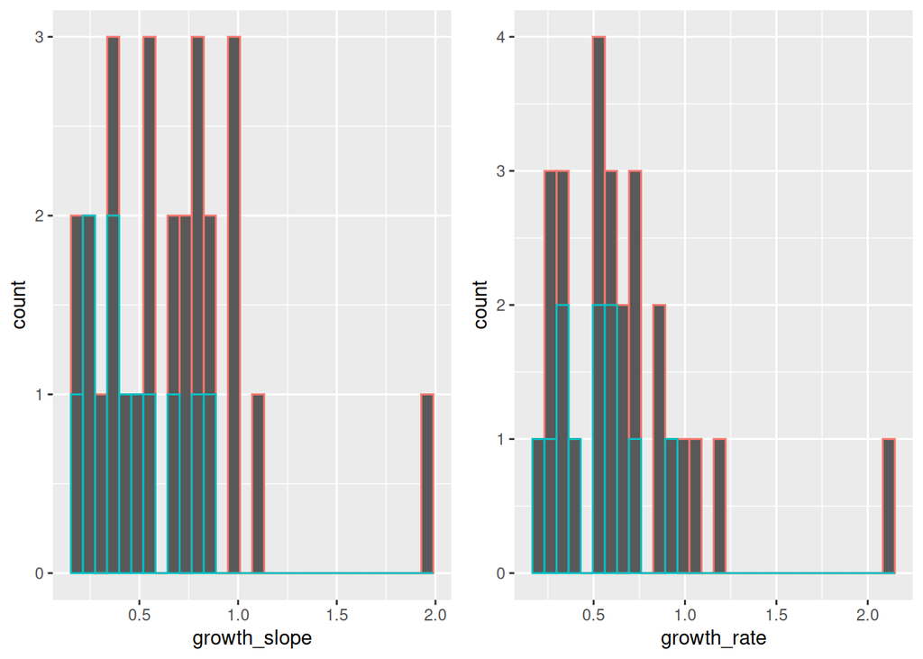

```r
p1 <- dd |> ggplot(aes(x=growth_slope, color=Sex)) + geom_histogram(show.legend = F)
p2 <- dd |> ggplot(aes(x=growth_rate, color=Sex)) + geom_histogram(show.legend = F)
cowplot::plot_grid(p1, p2)
```

For reference, fit linear mixed model:

```r
gr0 <- lmer(distance ~ age*Sex + (age|Subject), data=Orthodont)
gr0 |> tidy() |> filter(effect=="fixed")
```

```
## # A tibble: 4 × 6
##   effect group term          estimate std.error statistic
##   <chr>  <chr> <chr>            <dbl>     <dbl>     <dbl>
## 1 fixed  <NA>  (Intercept)     16.3      1.02      16.0
## 2 fixed  <NA>  age              0.784    0.0860     9.12
## 3 fixed  <NA>  SexFemale        1.03     1.60       0.647
## 4 fixed  <NA>  age:SexFemale   -0.305    0.135     -2.26
```

```r
gr1 <- lm(growth_slope ~ Sex, data=dd)
gr1 |> tidy()
```

```
## # A tibble: 2 × 5
##   term        estimate std.error statistic       p.value
##   <chr>          <dbl>     <dbl>     <dbl>         <dbl>
## 1 (Intercept)    0.784    0.0860      9.12 0.00000000199
## 2 SexFemale     -0.305    0.135      -2.26 0.0326
```

```r
gr2 <- lm(growth_rate ~ Sex, data=dd)
gr2 |> tidy()
```

```
## # A tibble: 2 × 5
##   term        estimate std.error statistic      p.value
##   <chr>          <dbl>     <dbl>     <dbl>        <dbl>
## 1 (Intercept)    0.766    0.0930      8.23 0.0000000139
## 2 SexFemale     -0.281    0.146      -1.93 0.0654
```

```r
document("_pbkrtest"); load_all("_pbkrtest")
```

[output not shown]

```r
gr1 |> fanova(test="pb")
```

```
##       stat df ddf p.value
## Sex 5.0292 NA  NA    0.03
```

```r
gr1 |> fanova(test="pbf")
```

```
##        stat      df     ddf p.value
## Sex  5.0292  1.0000 33.1130  0.0317
```

```r
gr2 |> fanova(test="x2")
```

```
##     stat   df ddf p.value
## Sex 3.74 1.00  NA  0.0531
```

```r
gr0 |> fanova()
```

```
##            stat      df     ddf p.value
## age     85.8418  1.0000 26.0000  0.0000
## Sex      7.4283  1.0000 25.0000  0.0116
## age:Sex  5.1208  1.0000 25.0000  0.0326
```

```r
fmodcomp(gr1, .~.-Sex)
```

```
## Parametric bootstrap test; n.ext: 37, n.boot: 1000, time: 0.4 sec
## growth_slope ~ Sex
## growth_slope ~ 1
##        stat df ddf p.value
## PBtest 5.03          0.038 *
## ---
## Signif. codes:  0 '***' 0.001 '**' 0.01 '*' 0.05 '.' 0.1 ' ' 1
```

```r
x <- PBrefdist(gr1, update(gr1, .~.-Sex))
```

anova(gr1)

X2modcomp(lmm_fit12, .~.-type)

fmodcomp(gr1, .~.-age:Sex, test=“X2”)

lg <- gr1

ff(gr1)

anova(gr1)

[output not shown]

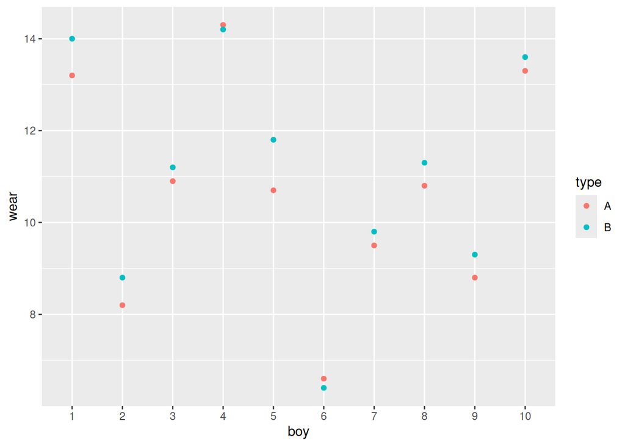

The plot shows that there is a large boy-to-boy variation in wear, and a much smaller variation between the two materials. The general tendency is that the wear of material B is larger than the wear of material A. Since the profiles are roughly parallel, there is no indication of interaction between boy and type.

It is reasonable to assume that the boys are independent, but that the wear of the two materials are correlated: A boy with high weat of material A is likely to have high wear of material B etc. This is supported by the correlation between the wear of the two materials:

```r
cor(shoes[, c("A","B")], use="pairwise.complete.obs")
```

```
##        A      B
## A 1.0000 0.9882
## B 0.9882 1.0000
```

### The paired $t$–test

One question to ask: Is material B significantly worse than material A? This can be answered by a paired $t$–test: Simply subtract the wear of material A from the wear of material B and test if the mean is different from zero. This way we get around the problem of repeated measurements on the same boy: We transform the problem into a problem that can be handled by standard statistical methods.

```r
## Maybe not tidy()
with(shoes, t.test(A, B), var.equal=T) |> tidy()
```

```
## # A tibble: 1 × 10
##   estimate estimate1 estimate2 statistic p.value parameter conf.low conf.high method                  alternative
##      <dbl>     <dbl>     <dbl>     <dbl>   <dbl>     <dbl>    <dbl>     <dbl> <chr>                   <chr>
## 1    -0.41      10.6      11.0    -0.369   0.717      18.0    -2.75      1.93 Welch Two Sample t-test two.sided
```

```r
with(shoes, t.test(A, B, paired=T), var.equal=T) |> tidy()
```

```
## # A tibble: 1 × 8
##   estimate statistic p.value parameter conf.low conf.high method        alternative
##      <dbl>     <dbl>   <dbl>     <dbl>    <dbl>     <dbl> <chr>         <chr>
## 1    -0.41     -3.35 0.00854         9   -0.687    -0.133 Paired t-test two.sided
```

```r
with(shoes, t.test(A - B)) |> tidy()
```

```
## # A tibble: 1 × 8
##   estimate statistic p.value parameter conf.low conf.high method            alternative
##      <dbl>     <dbl>   <dbl>     <dbl>    <dbl>     <dbl> <chr>             <chr>
## 1    -0.41     -3.35 0.00854         9   -0.687    -0.133 One Sample t-test two.sided
```

```r
lm(A - B ~ 1, data=shoes) |> tidy()
```

```
## # A tibble: 1 × 5
##   term        estimate std.error statistic p.value
##   <chr>          <dbl>     <dbl>     <dbl>   <dbl>
## 1 (Intercept)   -0.410     0.122     -3.35 0.00854
```

```r
with(shoes, t.test(A, B), var.equal=T) |> tidy()
```

```
## # A tibble: 1 × 10
##   estimate estimate1 estimate2 statistic p.value parameter conf.low conf.high method                  alternative
##      <dbl>     <dbl>     <dbl>     <dbl>   <dbl>     <dbl>    <dbl>     <dbl> <chr>                   <chr>
## 1    -0.41      10.6      11.0    -0.369   0.717      18.0    -2.75      1.93 Welch Two Sample t-test two.sided
```

### Working with linear models

One might be tempted to analyze data with a linear model with material (and boy) as effects:

```r
lm_fit1 <- lm(wear ~ type, data=shoes_long)
lm_fit2 <- lm(wear ~ type + boy, data=shoes_long)
lm_fit3 <- lm(B ~ A, data = shoes)
```

For both models, the estimated difference between the two materials is the same, but the standard errors differ by an order of magnitude:

```r
lm_fit1 |> tidy()
```

```
## # A tibble: 2 × 5
##   term        estimate std.error statistic  p.value
##   <chr>          <dbl>     <dbl>     <dbl>    <dbl>
## 1 (Intercept)    10.6      0.786    13.5   7.18e-11
## 2 typeB           0.41     1.11      0.369 7.16e- 1
```

```r
lm_fit2 |> tidy()
```

```
## # A tibble: 11 × 5
##    term        estimate std.error statistic  p.value
##    <chr>          <dbl>     <dbl>     <dbl>    <dbl>
##  1 (Intercept)   13.4       0.203    66.0   2.13e-13
##  2 typeB          0.41      0.122     3.35  8.54e- 3
##  3 boy2          -5.1       0.274   -18.6   1.70e- 8
##  4 boy3          -2.55      0.274    -9.31  6.44e- 6
##  5 boy4           0.65      0.274     2.37  4.16e- 2
##  6 boy5          -2.35      0.274    -8.58  1.26e- 5
##  7 boy6          -7.1       0.274   -25.9   9.08e-10
##  8 boy7          -3.95      0.274   -14.4   1.58e- 7
##  9 boy8          -2.55      0.274    -9.31  6.44e- 6
## 10 boy9          -4.55      0.274   -16.6   4.61e- 8
## 11 boy10         -0.150     0.274    -0.548 5.97e- 1
```

```r
lm_fit3 |> tidy()
```

```
## # A tibble: 2 × 5
##   term        estimate std.error statistic      p.value
##   <chr>          <dbl>     <dbl>     <dbl>        <dbl>
## 1 (Intercept)    0.247    0.605      0.409 0.693
## 2 A              1.02     0.0556    18.3   0.0000000829
```

The same is the case for the residual standard deviation:

```r
lm_fit1 |> glance()
```

```
## # A tibble: 1 × 12
##   r.squared adj.r.squared sigma statistic p.value    df logLik   AIC   BIC deviance df.residual  nobs
##       <dbl>         <dbl> <dbl>     <dbl>   <dbl> <dbl>  <dbl> <dbl> <dbl>    <dbl>       <int> <int>
## 1   0.00750       -0.0476  2.49     0.136   0.716     1  -45.5  97.1  100.     111.          18    20
```

```r
lm_fit2 |> glance()
```

```
## # A tibble: 1 × 12
##   r.squared adj.r.squared sigma statistic       p.value    df logLik   AIC   BIC deviance df.residual  nobs
##       <dbl>         <dbl> <dbl>     <dbl>         <dbl> <dbl>  <dbl> <dbl> <dbl>    <dbl>       <int> <int>
## 1     0.994         0.987 0.274      149. 0.00000000950    10   5.52  13.0  24.9    0.675           9    20
```

Under one model, there is absolutely no evidence of effect of materials, while under the other model, the effect is highly significant:

```r
anova(lm_fit1)
```

```
## Analysis of Variance Table
##
## Response: wear
##           Df Sum Sq Mean Sq F value Pr(>F)
## type       1    0.8    0.84    0.14   0.72
## Residuals 18  111.2    6.18
```

```r
anova(lm_fit2)
```

```
## Analysis of Variance Table
##
## Response: wear
##           Df Sum Sq Mean Sq F value  Pr(>F)
## type       1    0.8    0.84    11.2  0.0085 **
## boy        9  110.5   12.28   163.8 6.9e-09 ***
## Residuals  9    0.7    0.07
## ---
## Signif. codes:  0 '***' 0.001 '**' 0.01 '*' 0.05 '.' 0.1 ' ' 1
```

Another question one might ask is what is the wear of each material “in general”. For one model this is just intercept for material A and intercept + effect for material B. For the model with boy as a factor, one option is to calculate the prediction based for an “average boy”, which means adding the average of each boy to the intercept for material A and B. Such a quantity is called a least squares mean (LSmean):

```r
LSmeans(lm_fit1, ~type)  ## FIXME output is bad
```

```
##   type estimate std.error statistic df  p.value  lwr  upr
## 1    A     10.6     0.786      13.5 18 7.18e-11 8.98 12.3
## 2    B     11.0     0.786      14.0 18 3.84e-11 9.39 12.7
```

```r
LSmeans(lm_fit2, ~type)
```

```
##   type estimate std.error statistic df  p.value  lwr  upr
## 1    A     10.6    0.0866       123  9 8.00e-16 10.4 10.8
## 2    B     11.0    0.0866       128  9 5.69e-16 10.8 11.2
```

### Mixed models

```r
lmm_fit1 |> tidy()
```

```
## # A tibble: 4 × 6
##   effect   group    term            estimate std.error statistic
##   <chr>    <chr>    <chr>              <dbl>     <dbl>     <dbl>
## 1 fixed    <NA>     (Intercept)       10.6       0.786     13.5
## 2 fixed    <NA>     typeB              0.410     0.122      3.35
## 3 ran_pars boy      sd__(Intercept)    2.47     NA         NA
## 4 ran_pars Residual sd__Observation    0.274    NA         NA
```

```r
load_all("_pbkrtest")
```

```
## ℹ Loading pbkrtest
```

```r
an <- anova(lmm_fit1, lmm_fit0, test="Chisq" )
```

```
## refitting model(s) with ML (instead of REML)
```

```r
an
```

```
## Data: shoes_long
## Models:
## lmm_fit0: wear ~ (1 | boy)
## lmm_fit1: wear ~ type + (1 | boy)
##          npar  AIC  BIC logLik deviance Chisq Df Pr(>Chisq)
## lmm_fit0    3 67.9 70.9  -30.9     61.9
## lmm_fit1    4 61.8 65.8  -26.9     53.8  8.09  1     0.0044 **
## ---
## Signif. codes:  0 '***' 0.001 '**' 0.01 '*' 0.05 '.' 0.1 ' ' 1
```

```r
str(an)
```

```
## Classes 'anova' and 'data.frame':    2 obs. of  8 variables:
##  $ npar      : num  3 4
##  $ AIC       : num  67.9 61.8
##  $ BIC       : num  70.9 65.8
##  $ logLik    : num  -31 -26.9
##  $ deviance  : num  61.9 53.8
##  $ Chisq     : num  NA 8.09
##  $ Df        : num  NA 1
##  $ Pr(>Chisq): num  NA 0.00445
##  - attr(*, "heading")= chr [1:4] "Data: shoes_long" "Models:" "lmm_fit0: wear ~ (1 | boy)" "lmm_fit1: wear ~ type + (1 | boy)"
```

```r
anova(lmm_fit1, update(lmm_fit1, .~.-type), test="Chisq" )
```

```
## refitting model(s) with ML (instead of REML)
```

```
## Data: shoes_long
## Models:
## update(lmm_fit1, . ~ . - type): wear ~ (1 | boy)
## lmm_fit1: wear ~ type + (1 | boy)
##                                npar  AIC  BIC logLik deviance Chisq Df Pr(>Chisq)
## update(lmm_fit1, . ~ . - type)    3 67.9 70.9  -30.9     61.9
## lmm_fit1                          4 61.8 65.8  -26.9     53.8  8.09  1     0.0044 **
## ---
## Signif. codes:  0 '***' 0.001 '**' 0.01 '*' 0.05 '.' 0.1 ' ' 1
```

```r
krb <- KRmodcomp(lmm_fit1, .~.-type)
ss <- summary( krb )
krb
```

```
## wear ~ type + (1 | boy)
## wear ~ (1 | boy)
##          stat   df  ddf p.value
## KR_Ftest 11.2  1.0  9.0  0.0085 **
## ---
## Signif. codes:  0 '***' 0.001 '**' 0.01 '*' 0.05 '.' 0.1 ' ' 1
```

```r
ss
```

```
## F-test with Kenward-Roger approximation
## wear ~ type + (1 | boy)
## wear ~ (1 | boy)
##            stat    df ddf p.value
## LRT        8.09  1.00      0.0044 **
## KR_Ftest  11.21  1.00   9  0.0085 **
## KR_FtestU 11.21  1.00   9  0.0085 **
## ---
## Signif. codes:  0 '***' 0.001 '**' 0.01 '*' 0.05 '.' 0.1 ' ' 1
```

```r
load_all("_pbkrtest")
```

```
## ℹ Loading pbkrtest
```

```r
satb <- SATmodcomp(lmm_fit1, .~.-type)
ss <- summary(satb)
satb
```

```
## wear ~ type + (1 | boy)
## wear ~ (1 | boy)
##           stat   df ddf p.value
## SAT_Ftest 11.2  1.0   9  0.0085 **
## ---
## Signif. codes:  0 '***' 0.001 '**' 0.01 '*' 0.05 '.' 0.1 ' ' 1
```

```r
satb$p.value
```

```
## [1] 0.008539
```

```r
ss
```

```
## F-test with Satterthwaite approximation
## wear ~ type + (1 | boy)
## wear ~ (1 | boy)
##            stat    df ddf p.value
## LRT        8.09  1.00      0.0044 **
## SAT_Ftest 11.21  1.00   9  0.0085 **
## ---
## Signif. codes:  0 '***' 0.001 '**' 0.01 '*' 0.05 '.' 0.1 ' ' 1
```

```r
pbb <- PBmodcomp(lmm_fit1, .~. - type)
ss <- summary(pbb)
ss
```

```
## Parametric bootstrap test; n.ext: 9, n.boot: 1000, time: 3.7 sec
## wear ~ type + (1 | boy)
## wear ~ (1 | boy)
##        stat   df ddf p.value
## LRT    8.09 1.00      0.0044 **
## PBtest 8.09           0.0100 **
## NA
## ---
## Signif. codes:  0 '***' 0.001 '**' 0.01 '*' 0.05 '.' 0.1 ' ' 1
```

```r
pbb <- PBmodcomp(lmm_fit1, .~. - type, nsim=10)
ss <- summary(pbb)
ss
```

```
## Parametric bootstrap test; n.ext: 0, n.boot: 8, time: 0.1 sec
## wear ~ type + (1 | boy)
## wear ~ (1 | boy)
##        stat   df ddf p.value
## LRT    8.09 1.00      0.0044 **
## PBtest 8.09           0.1111
## NA
## ---
## Signif. codes:  0 '***' 0.001 '**' 0.01 '*' 0.05 '.' 0.1 ' ' 1
```

```r
load_all("_pbkrtest")
```

```
## ℹ Loading pbkrtest
```

```r
apbb <- seqPBmodcomp(lmm_fit1, update(lmm_fit1,.~. - type))
ass <- summary(apbb)
apbb
```

```
## Parametric bootstrap test; n.ext: 12, n.boot: 1000, time: 9.7 sec
## wear ~ type + (1 | boy)
## wear ~ (1 | boy)
##        stat df ddf p.value
## PBtest 8.09          0.013 *
## ---
## Signif. codes:  0 '***' 0.001 '**' 0.01 '*' 0.05 '.' 0.1 ' ' 1
```

```r
apbb$p.value
```

```
## [1] 0.01299
```

```r
ass
```

```
## Parametric bootstrap test; n.ext: 12, n.boot: 1000, time: 9.7 sec
## wear ~ type + (1 | boy)
## wear ~ (1 | boy)
##        stat   df ddf p.value
## LRT    8.09 1.00      0.0044 **
## PBtest 8.09           0.0130 *
## NA
## ---
## Signif. codes:  0 '***' 0.001 '**' 0.01 '*' 0.05 '.' 0.1 ' ' 1
```

```r
pbb$p.value
```

```
## [1] 0.1111
```

```r
source("nlme.R")
data("Orthodont")

.get_refdist_gls <- function(lg, sm, nsim=20, seed=NULL,
                    simdata=simulate(sm, nsim=nsim, seed=NULL)){

    ## simdata |>  print()
    val <- list()
    for (i in 1:ncol(simdata)){
        yyy <- simdata[,i]
        sm2 <- refit_gls(sm, yyy)
        lg2 <- refit_gls(lg, yyy)

        lsm <- logLik(sm2, REML=FALSE)
        llg <- logLik(lg2, REML=FALSE)
        v <- c(llg, lsm, 2*(llg-lsm))
        val <- c(val, list(v))
    }

    val <- do.call(rbind, val)
    val[,3]
}



mm1 <- lme(distance ~ age, random = ~ age | Subject,
                 correlation = corAR1(form = ~ 1 | Subject), data = Orthodont, method="ML")

mm1 <- lme(distance ~ age, random = ~ age | Subject,
                 data = Orthodont, method="ML")


mm0 <- update(mm1, .~.-age)

## PBrefdist(mm1,mm0)

sm <- mm0
lg <- mm1

VVV <- compute_full_covariance_matrix(mm1)

fitted(mm1)
```

[output not shown]

```r
bb <- fixef(mm1)
vbb <- vcov(mm1)
```